# Morris Warmaking

Bernhard Koschicek

# War-making capacity

## War-making capacity plot

Here out first dataset will be plotted and visualized. The y axis of the plot diagram is resized to 0.3 because of the explotion of warmaking capacity in the last 200 years. To better visualise the sublte changes across the centuries this was a necessary step.

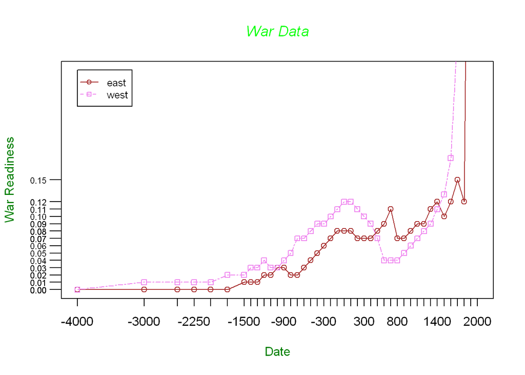

```r
# Load csv
morris_warmaking <- read.delim("C:/Users/bkoschicek/Dropbox/Geschichte Studium/3_Sem/R-repo/03/morris_warmaking.csv")

# Asign variables
east = morris_warmaking$East
west = morris_warmaking$West
date = morris_warmaking$Date

#PDF output
#pdf(file="C:/Users/bkoschicek/Dropbox/Geschichte Studium/3_Sem/R-repo/03/figure.pdf", height=3.5, width=5)

# Create Plot
plot(date, east, type="o", col="brown", axes=FALSE, ann=FALSE, ylim=c(0,0.3))

# Name and config axis
axis(1, at=date, lab=date)
axis(2, at=east, las=1, tck=-0.05, cex.axis=0.7)
# Putting a box around
box()

# Add data west
lines(date, west, type="o", pch=22, lty=6, col="violet")

# Labeling of the axis and diagram
title(main="War Data", col.main="green", font.main=3)
title(xlab="Date", col.lab=rgb(0,0.5,0))
title(ylab="War Readiness", col.lab=rgb(0,0.5,0))

# Creating the legend
legend(-4000, y= 0.3, c("east","west"), cex=0.8, col=c("brown","violet"), pch=21:22, lty=1:2)
```

```r
#PDF output
#dev.off()
```

## Who was in lead

This table represents who was in lead at the given time. We have a Date columne and tree columns for West, East and Equal. Whoever was in lead will get a True value.

```r
# Load csv
morris_warmaking <- read.delim("C:/Users/bkoschicek/Dropbox/Geschichte Studium/3_Sem/R-repo/03/morris_warmaking.csv")

# Asign variables
east = morris_warmaking$East
west = morris_warmaking$West
date = morris_warmaking$Date

# Make comparision and asign them to the values
west = morris_warmaking$West >  morris_warmaking$East
east = morris_warmaking$West <  morris_warmaking$East
equal = morris_warmaking$West ==  morris_warmaking$East

# Determine who was "better". I squeezed my brain for a better and fancy solution, but hours of thinking were pointless, so here is the simply not beautyful solution, I'm sorry.

x = data.frame("Date" = morris_warmaking$Date, "West_better" = west, "East_better" = east,  "Equal" = equal)
x
```

```
##     Date West_better East_better Equal
## 1  -4000       FALSE       FALSE  TRUE
## 2  -3000        TRUE       FALSE FALSE
## 3  -2500        TRUE       FALSE FALSE
## 4  -2250        TRUE       FALSE FALSE
## 5  -2000        TRUE       FALSE FALSE
## 6  -1750        TRUE       FALSE FALSE
## 7  -1500        TRUE       FALSE FALSE
## 8  -1400        TRUE       FALSE FALSE
## 9  -1300        TRUE       FALSE FALSE
## 10 -1200        TRUE       FALSE FALSE
## 11 -1100        TRUE       FALSE FALSE
## 12 -1000       FALSE       FALSE  TRUE
## 13  -900        TRUE       FALSE FALSE
## 14  -800        TRUE       FALSE FALSE
```

[output cut: 28 more lines]

# Maximum Settlement Sizes

## Fix the dataset

> Fix the dataset so that it confirms to the principles of tidy data. What should be corrected?

Here are some points how I fixed my dataset. I’m sure I forgort things but well there is so much to do and so little time:

- Get the whole thing in a table format with RegEx: `^(\W?\d+)\W(\S+)\s+([^\d]+)([^\s]+)\s+(.+)`
- The comma from the size column is interprated as decimal, so it has to be changed to . or nothing.
- kill the author because he wrote “perhaps 500” in the western table for Mareybet and didn’t asign a value for the points. In this case I just added the value NA to the table by myself and wrote the “perhaps” manually to the size, because I didn’t want to change my regex just for a single entry
- One problem could be the 4 date of the western table because there the author starts with 8000 BCE. I would just ignore this and hope that the plot will to the right thing here and just start the eastern values at 4000 BCE
- Commas are not supported in plot, therefore we have to change it and delete them
- Sometime there are inconsistencies like in the settlements column one time the author wrote ´London and Constantinople´

> The datasets for the East and the West are separate. What would be your strategies to combine them?

There are as always more ways to do this. I would clearly add another column with the header alignment (?!) to it and fill the cells with the values eastern/western, so I can use them in a single csv file. But out of convinience I just would import the files separetly for the visualisation. If we go really fancy and we don’t have the alignment of the Settlements, I’m sure we could reference the Settlementnames with a gazetteer to get their geographical position and meta information.

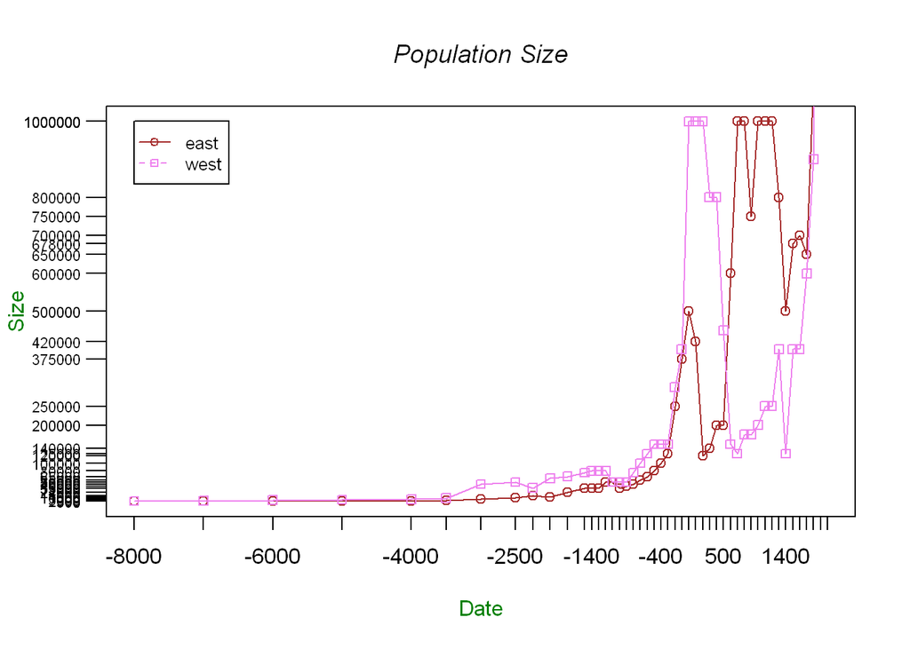

```r
# Loading dataset and asign to variable

eastern <- read.csv("C:/Users/bkoschicek/Dropbox/Geschichte Studium/3_Sem/R-repo/03/settlements/morris_settlement_eastern.csv", sep=";")
western <- read.csv("C:/Users/bkoschicek/Dropbox/Geschichte Studium/3_Sem/R-repo/03/settlements/morris_settlement_western.csv", sep=";")
dates = western$Date

west_set = western$Settlement
west_size = western$Size
west_point = western$Points

east_set = eastern$Settlement
east_size = eastern$Size
east_point = eastern$Points

# Plot the population size (note the y axis is limited to 1,000,000 because of the population growth)
plot(dates, east_size, type="o", col="brown", axes=FALSE, ann=FALSE, ylim=c(0,1000000))

## Axis and boxing
axis(1, at=dates, lab=dates)
axis(2, at=east_size, las=1, tck=-0.05, cex.axis=0.7)
box()

## Add new data line
lines(dates, west_size, type="o", pch=22, col="violet")

## labeling
title(main="Population Size", col.main="black", font.main=3)
title(xlab="Date", col.lab=rgb(0,0.5,0))
title(ylab="Size", col.lab=rgb(0,0.5,0))

## Add legend
legend(-8000, y= 1000000, c("east","west"), cex=0.8, col=c("brown","violet"), pch=21:22, lty=1:2)
```

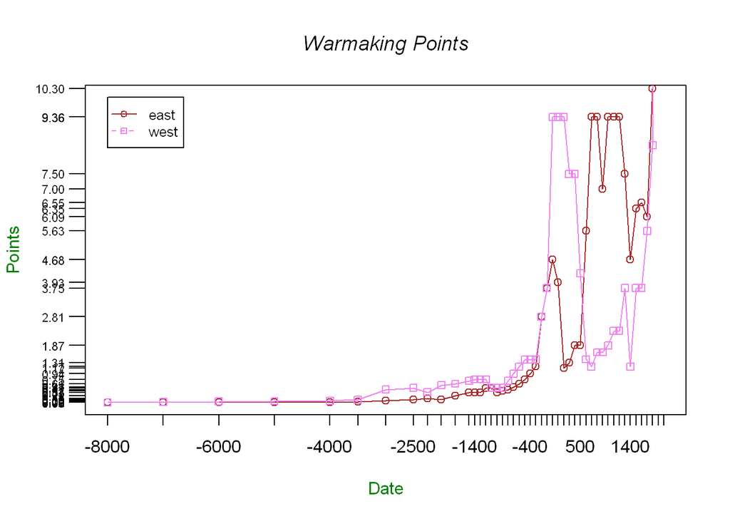

```r
# Plot for the warmaking points
plot(dates, east_point, type="o", col="brown", axes=FALSE, ann=FALSE, ylim=c(0,10))

## Axis and boxing
axis(1, at=dates, lab=dates)
axis(2, at=east_point, las=1, tck=-0.05, cex.axis=0.7)
box()

## Add data line
lines(dates, west_point, type="o", pch=22, col="violet")

## labeling
title(main="Warmaking Points", col.main="black", font.main=3)
title(xlab="Date", col.lab=rgb(0,0.5,0))
title(ylab="Points", col.lab=rgb(0,0.5,0))

## Add legend
legend(-8000, y= 10, c("east","west"), cex=0.8, col=c("brown","violet"), pch=21:22, lty=1:2)
```

```r
# Who was better and which Settlements were the top

## Comparison
west = west_point >  east_point
east = west_point <  east_point
equal = west_point == east_point

## Make a data frame
better_whole = data.frame("dates_lead" = dates, "West_better" = west, "East_better" = east,  "Equal" = equal, "Western_Cities" = west_set, "Eastern_Cities" = east_set)

# I think this is not a nice solution but I cannot make a valid if statement in a for each with data frames... this is frustrating...

## Create dataset of whom was better at a given time
western_data = data.frame("dates_lead" = dates, "West_better" = west, "Western_Cities" = west_set)
west_lead = subset(western_data,  West_better == TRUE)
west_lead$West_better = "W"
eastern_data = data.frame("dates_lead" = dates, "East_better" = east, "Eastern_Cities" = east_set)
east_lead = subset(eastern_data,  East_better == TRUE)
east_lead$East_better = "E"

d = merge(western_data, eastern_data, by.x = "dates_lead", sort = TRUE)
d
```

```
##    dates_lead West_better                 Western_Cities East_better
## 1       -8000       FALSE         Mureybet                     FALSE
## 2       -7000        TRUE     Beidha, Basta, catalhoyiik       FALSE
## 3       -6000        TRUE     catalhoyilk                      FALSE
## 4       -5000        TRUE     Tell Brak                        FALSE
## 5       -4000        TRUE     Uruk, Tell Brak                  FALSE
## 6       -3500        TRUE     Uruk, Susa, Tell Brak            FALSE
## 7       -3000        TRUE      Uruk                            FALSE
## 8       -2500        TRUE      Uruk                            FALSE
## 9       -2250        TRUE      Akkad, Memphis                  FALSE
## 10      -2000        TRUE      Memphis, Ur                     FALSE
## 11      -1750        TRUE      Babylon                         FALSE
## 12      -1500        TRUE      Uruk, Thebes                    FALSE
## 13      -1400        TRUE      Thebes                          FALSE
## 14      -1300        TRUE      Thebes                          FALSE
```

[output cut: 81 more lines]

```r
## Loading plyr package
library("plyr")
library("tidyr")
library("dplyr")
## Bringing the two tables together
total_lead = rbind.fill(west_lead, east_lead)
attach(total_lead)
newdata = total_lead[order(dates_lead),]
detach(total_lead)
# newdata
newdata[is.na(newdata)] <- ""
## Well I looked at the reading we had to tidy my tables and replace the NAs with an empty string to `unite` the datasets, since unite strangely doesn't kill NAs. So I found in the reading the replace_na function, sounded nice, but even the test code at the r documentation worked! ( https://www.rdocumentation.org/packages/tidyr/versions/0.8.3/topics/replace_na ) So I have no idea how to change NAs in fctr to an empty string. I searched a lot and tried a lot, but nothing changed really. At least some fishy code `newdata[is.na(newdata)] <- ""` worked on the chr data.

# newdata %>% replace_na(list(Western_Cities = 0))
# newdata

uniteddata = unite(newdata,"Better", "West_better", "East_better", sep = "", remove = TRUE)
# u = unite(uniteddata, "Cities", "Western_Cities", "Eastern_Cities", sep = "", remove = TRUE)
# # u[is.na(u)] <- ""
uniteddata
```

```
##    dates_lead Better               Western_Cities
## 1       -7000      W   Beidha, Basta, catalhoyiik
## 2       -6000      W   catalhoyilk
## 3       -5000      W   Tell Brak
## 4       -4000      W   Uruk, Tell Brak
## 5       -3500      W   Uruk, Susa, Tell Brak
## 6       -3000      W    Uruk
## 7       -2500      W    Uruk
## 8       -2250      W    Akkad, Memphis
## 9       -2000      W    Memphis, Ur
## 10      -1750      W    Babylon
## 11      -1500      W    Uruk, Thebes
## 12      -1400      W    Thebes
## 13      -1300      W    Thebes
## 14      -1200      W    Babylon, Thebes
```

[output cut: 73 more lines]

# Datasets

```r
morris_warmaking
```

```
##     Date BCE.CE   West  East
## 1  -4000    BCE   0.00  0.00
## 2  -3000    BCE   0.01  0.00
## 3  -2500    BCE   0.01  0.00
## 4  -2250    BCE   0.01  0.00
## 5  -2000    BCE   0.01  0.00
## 6  -1750    BCE   0.02  0.00
## 7  -1500    BCE   0.02  0.01
## 8  -1400    BCE   0.03  0.01
## 9  -1300    BCE   0.03  0.01
## 10 -1200    BCE   0.04  0.02
## 11 -1100    BCE   0.03  0.02
## 12 -1000    BCE   0.03  0.03
## 13  -900    BCE   0.04  0.03
## 14  -800    BCE   0.05  0.02
```

[output cut: 28 more lines]

```r
eastern
```

```
##     Date BCE.CE                                   Settlement     Size
## 1  -8000    BCE                             NA                      0
## 2  -7000    BCE                                         NA          0
## 3  -6000    BCE                            NA                       0
## 4  -5000    BCE                          NA                         0
## 5  -4000    BCE            Jiangzhai, Jiahu                       300
## 6  -3500    BCE             Xipo                                 2000
## 7  -3000    BCE             Dadiwan                              5000
## 8  -2500    BCE Taosi, Liangchengzhen, Yaowangcheng             10000
## 9  -2250    BCE Taosi, Liangchengzhen, Yaowangcheng             14000
## 10 -2000    BCE              Fengcheng,Nanshui                  11000
## 11 -1750    BCE              Erlitou                            24000
## 12 -1500    BCE              Zhengzhou                          35000
## 13 -1400    BCE              Zhengzhou                          35000
## 14 -1300    BCE              Zhengzhou                          35000
```

[output cut: 81 more lines]

```r
western
```

```
##     Date BCE.CE                     Settlement     Size Points Alignment
## 1  -8000    BCE         Mureybet                    500   0.00   western
## 2  -7000    BCE     Beidha, Basta, catalhoyiik     1000   0.01   western
## 3  -6000    BCE     catalhoyilk                    3000   0.03   western
## 4  -5000    BCE     Tell Brak                      4000   0.04   western
## 5  -4000    BCE     Uruk, Tell Brak                5000   0.05   western
## 6  -3500    BCE     Uruk, Susa, Tell Brak          8000   0.09   western
## 7  -3000    BCE      Uruk                         45000   0.42   western
## 8  -2500    BCE      Uruk                         50000   0.47   western
## 9  -2250    BCE      Akkad, Memphis               35000   0.33   western
## 10 -2000    BCE      Memphis, Ur                  60000   0.56   western
## 11 -1750    BCE      Babylon                      65000   0.61   western
## 12 -1500    BCE      Uruk, Thebes                 75000   0.70   western
## 13 -1400    BCE      Thebes                       80000   0.75   western
## 14 -1300    BCE      Thebes                       80000   0.75   western
```

[output cut: 33 more lines]